# Manipulating data

This guide is partly based on online material from Amy Willis, Kiirsti Owen and Amelia McNamara, and the book “R for Data Science” by Hadley Wickham and Garrett Grolemund. Thank you amazing R community!

### Load packages

We will be using the readr, tidyr and dplyr packages from the Tidyverse family of packages. We will also load the “here” package that we will use to read in our data.

```r
library(readr)
library(tidyr)
library(dplyr)
library(here)
```

### First, let’s practice with pivoting

We will start with a toy non-tidy dataset:

```r
patient_ID <- c(1,2)
test_result_month1 <- c("a1" ,"a2")
test_result_month2 <- c("b1" ,"b2")
test_result_month3 <- c("c1" ,"c2")

patient_tests <- data.frame(patient_ID,test_result_month1,test_result_month2,test_result_month3)

patient_tests
```

| patient_ID | test_result_month1 | test_result_month2 | test_result_month3 |
| --- | --- | --- | --- |
| 1 | a1 | b1 | c1 |
| 2 | a2 | b2 | c2 |

The dataset is not tidy because each row contains three observations, one per month. A tidy dataset has one observation per row. To do this, we use pivot_longer.

- The first argument is the dataset to reshape, but as we are using the pipe (%>%) we are skipping the first argument.
- The next argument describes which columns need to be reshaped. In this case, it’s every column apart from patient_ID.
- The names_to gives the name of the variable that will be created from the data stored in the column names, in this case the month.
- The values_to gives the name of the variable that will be created from the data stored in the cell value, in this case the test result.

```r
tidy_patient_tests <- patient_tests %>%
  pivot_longer(
    c('test_result_month1','test_result_month2','test_result_month3'),
    names_to= 'month',
    values_to='test_result'
    )

tidy_patient_tests
```

| patient_ID | month | test_result |
| --- | --- | --- |
| 1 | test_result_month1 | a1 |
| 1 | test_result_month2 | b1 |
| 1 | test_result_month3 | c1 |
| 2 | test_result_month1 | a2 |
| 2 | test_result_month2 | b2 |
| 2 | test_result_month3 | c2 |

As you can see, the data frame is now tidy (one observation per row), but it would be better if the “month” column just contained the month number (1,2,3). To do this we can add the arguments names_prefix to strip off the test_result_month prefix, and names_transform to convert month into an integer:

```r
tidy_patient_tests <- patient_tests %>%
  pivot_longer(
    c('test_result_month1','test_result_month2','test_result_month3'),
    names_to= 'month',
    names_prefix = 'test_result_month',
    names_transform = list(month = as.integer),
    values_to='test_result'
    )
tidy_patient_tests
```

| patient_ID | month | test_result |
| --- | --- | --- |
| 1 | 1 | a1 |
| 1 | 2 | b1 |
| 1 | 3 | c1 |
| 2 | 1 | a2 |
| 2 | 2 | b2 |
| 2 | 3 | c2 |

### Reading in the FEV data

We will use the same data as last week. So read in the data from file fev.csv and save it in an object called fev_data:

```r
# Add your code here!
fev_data <- read_csv(here("./Inputs/fev.csv"))
```

Tip: If you got an error that “fev.csv” does not exist, check that you are working in the correct directory!

### Operating on data: subsets

To select subsets of the data (not just columns with $) use square brackets:

```r
fev_data$fev[32] # 32nd element of the fev column
```

```
## [1] 3
```

```r
fev_data[32,3] # 32nd element of the 3rd column
```

| age |
| --- |
| 9 |

```r
fev_data[32,"age"]  # Same thing, but using the name of the 3rd column - better, as it is more readable and robust
```

| age |
| --- |
| 9 |

```r
fev_data[32, ] # Everything in the 3rd row
```

| seqnbr | subjid | age | fev | height | sex | smoke |
| --- | --- | --- | --- | --- | --- | --- |
| 32 | 7201 | 9 | 3 | 65.5 | 1 | 0 |

```r
fev_data[32,1:3]
```

| seqnbr | subjid | age |
| --- | --- | --- |
| 32 | 7201 | 9 |

```r
fev_data[32,-5]
```

| seqnbr | subjid | age | fev | sex | smoke |
| --- | --- | --- | --- | --- | --- |
| 32 | 7201 | 9 | 3 | 1 | 0 |

```r
fev_data[32,-1:-2]
```

| age | fev | height | sex | smoke |
| --- | --- | --- | --- | --- |
| 9 | 3 | 65.5 | 1 | 0 |

```r
fev_data[32,c(1,3,5)] #c(1,3,5) is a vector of numbers (c means "combine")
```

| seqnbr | age | height |
| --- | --- | --- |
| 32 | 9 | 65.5 |

```r
c(1,3,5) %>%
  length
```

```
## [1] 3
```

–> How would you drop the 1st, 3rd and 5th column?

```r
# Add your code here!
fev_data[,c(2,4,6,7)]
```

| subjid | fev | sex | smoke |
| --- | --- | --- | --- |
| 301 | 1.708 | 0 | 0 |
| 451 | 1.724 | 0 | 0 |
| 501 | 1.720 | 0 | 0 |
| 642 | 1.558 | 1 | 0 |
| 901 | 1.895 | 1 | 0 |
| 1701 | 2.336 | 0 | 0 |
| 1752 | 1.919 | 0 | 0 |
| 1753 | 1.415 | 0 | 0 |
| 1901 | 1.987 | 0 | 0 |
| 1951 | 1.942 | 0 | 0 |

[output cut: 644 more lines]

### Logicals

Besides numbers and strings of characters, R also stores logicals - TRUE and FALSE

Example: a new vector with elements that are TRUE if height is above 72 cm and FALSE otherwise:

```r
is_tall <- fev_data$height > 72
```

Useful summary command:

```r
table(is_tall)
```

```
## is_tall
## FALSE  TRUE
##   647     7
```

Which subjects in fev_data are tall?

```r
fev_data[is_tall,]
```

| seqnbr | subjid | age | fev | height | sex | smoke |
| --- | --- | --- | --- | --- | --- | --- |
| 401 | 18841 | 14 | 4.273 | 72.5 | 1 | 0 |
| 450 | 32741 | 13 | 4.225 | 74.0 | 1 | 0 |
| 464 | 37241 | 13 | 4.877 | 73.0 | 1 | 0 |
| 517 | 49541 | 13 | 5.083 | 74.0 | 1 | 0 |
| 550 | 59941 | 14 | 4.271 | 72.5 | 1 | 0 |
| 632 | 37441 | 17 | 5.633 | 73.0 | 1 | 0 |
| 636 | 44241 | 16 | 3.645 | 73.5 | 1 | 0 |

### Filtering (selecting rows)

```r
fev_data %>%
  filter(height > 72)
```

| seqnbr | subjid | age | fev | height | sex | smoke |
| --- | --- | --- | --- | --- | --- | --- |
| 401 | 18841 | 14 | 4.273 | 72.5 | 1 | 0 |
| 450 | 32741 | 13 | 4.225 | 74.0 | 1 | 0 |
| 464 | 37241 | 13 | 4.877 | 73.0 | 1 | 0 |
| 517 | 49541 | 13 | 5.083 | 74.0 | 1 | 0 |
| 550 | 59941 | 14 | 4.271 | 72.5 | 1 | 0 |
| 632 | 37441 | 17 | 5.633 | 73.0 | 1 | 0 |
| 636 | 44241 | 16 | 3.645 | 73.5 | 1 | 0 |

```r
fev_data %>%
  filter(age == 6)
```

| seqnbr | subjid | age | fev | height | sex | smoke |
| --- | --- | --- | --- | --- | --- | --- |
| 7 | 1752 | 6 | 1.919 | 58.0 | 0 | 0 |
| 8 | 1753 | 6 | 1.415 | 56.0 | 0 | 0 |
| 11 | 1952 | 6 | 1.602 | 53.0 | 0 | 0 |
| 18 | 3551 | 6 | 1.878 | 53.0 | 0 | 0 |
| 49 | 10841 | 6 | 1.650 | 55.0 | 1 | 0 |
| 55 | 12241 | 6 | 1.634 | 54.0 | 1 | 0 |
| 63 | 14251 | 6 | 1.481 | 51.0 | 0 | 0 |
| 66 | 14541 | 6 | 1.747 | 57.5 | 1 | 0 |
| 80 | 16151 | 6 | 1.719 | 53.0 | 0 | 0 |
| 82 | 16252 | 6 | 1.695 | 53.0 | 0 | 0 |

[output cut: 27 more lines]

```r
fev_data %>%
  filter(age != 20)
```

| seqnbr | subjid | age | fev | height | sex | smoke |
| --- | --- | --- | --- | --- | --- | --- |
| 1 | 301 | 9 | 1.708 | 57.0 | 0 | 0 |
| 2 | 451 | 8 | 1.724 | 67.5 | 0 | 0 |
| 3 | 501 | 7 | 1.720 | 54.5 | 0 | 0 |
| 4 | 642 | 9 | 1.558 | 53.0 | 1 | 0 |
| 5 | 901 | 9 | 1.895 | 57.0 | 1 | 0 |
| 6 | 1701 | 8 | 2.336 | 61.0 | 0 | 0 |
| 7 | 1752 | 6 | 1.919 | 58.0 | 0 | 0 |
| 8 | 1753 | 6 | 1.415 | 56.0 | 0 | 0 |
| 9 | 1901 | 8 | 1.987 | 58.5 | 0 | 0 |
| 10 | 1951 | 9 | 1.942 | 60.0 | 0 | 0 |

[output cut: 644 more lines]

```r
fev_data %>%
  filter(age <= 20)
```

| seqnbr | subjid | age | fev | height | sex | smoke |
| --- | --- | --- | --- | --- | --- | --- |
| 1 | 301 | 9 | 1.708 | 57.0 | 0 | 0 |
| 2 | 451 | 8 | 1.724 | 67.5 | 0 | 0 |
| 3 | 501 | 7 | 1.720 | 54.5 | 0 | 0 |
| 4 | 642 | 9 | 1.558 | 53.0 | 1 | 0 |
| 5 | 901 | 9 | 1.895 | 57.0 | 1 | 0 |
| 6 | 1701 | 8 | 2.336 | 61.0 | 0 | 0 |
| 7 | 1752 | 6 | 1.919 | 58.0 | 0 | 0 |
| 8 | 1753 | 6 | 1.415 | 56.0 | 0 | 0 |
| 9 | 1901 | 8 | 1.987 | 58.5 | 0 | 0 |
| 10 | 1951 | 9 | 1.942 | 60.0 | 0 | 0 |

[output cut: 644 more lines]

You can also filter by whether data are not a number (na):

```r
fev_data %>%
  filter(is.na(age))  # opposite: !is.na(age)
```

| seqnbr | subjid | age | fev | height | sex | smoke |
| --- | --- | --- | --- | --- | --- | --- |

You can combine multiple expressions with Boolean operators: & is “and”, | is “or”, and ! is “not”

```r
fev_data %>%
  filter(age == 14 & smoke !=0)   # age is 14 AND smoker
```

| seqnbr | subjid | age | fev | height | sex | smoke |
| --- | --- | --- | --- | --- | --- | --- |
| 332 | 4952 | 14 | 2.236 | 66 | 0 | 1 |
| 358 | 10053 | 14 | 3.428 | 64 | 0 | 1 |
| 370 | 11642 | 14 | 3.957 | 72 | 1 | 1 |
| 384 | 15751 | 14 | 3.074 | 65 | 0 | 1 |
| 439 | 30042 | 14 | 4.309 | 69 | 1 | 1 |
| 556 | 61941 | 14 | 2.276 | 66 | 1 | 1 |
| 602 | 82743 | 14 | 4.763 | 68 | 1 | 1 |

```r
fev_data %>%
  filter(age < 5 | height < 50)  # younger than 5 OR shorter than 50 cm
```

| seqnbr | subjid | age | fev | height | sex | smoke |
| --- | --- | --- | --- | --- | --- | --- |
| 21 | 4351 | 5 | 1.400 | 49.0 | 0 | 0 |
| 23 | 5152 | 4 | 0.839 | 48.0 | 0 | 0 |
| 26 | 5642 | 3 | 1.404 | 51.5 | 1 | 0 |
| 31 | 6851 | 5 | 1.282 | 49.0 | 0 | 0 |
| 59 | 13751 | 4 | 1.569 | 50.0 | 0 | 0 |
| 64 | 14252 | 4 | 1.577 | 49.0 | 0 | 0 |
| 104 | 23841 | 4 | 0.796 | 47.0 | 1 | 0 |
| 118 | 28551 | 5 | 1.196 | 46.5 | 0 | 0 |
| 157 | 38242 | 6 | 1.536 | 48.0 | 1 | 0 |
| 173 | 40541 | 4 | 1.789 | 52.0 | 1 | 0 |

[output cut: 8 more lines]

Rules for filtering for categorical data: sex == “F” or sex != “F” sex %in% c(“M”,“F”)

### Selecting columns

```r
fev_data %>%
  select(fev, height, age)
```

| fev | height | age |
| --- | --- | --- |
| 1.708 | 57.0 | 9 |
| 1.724 | 67.5 | 8 |
| 1.720 | 54.5 | 7 |
| 1.558 | 53.0 | 9 |
| 1.895 | 57.0 | 9 |
| 2.336 | 61.0 | 8 |
| 1.919 | 58.0 | 6 |
| 1.415 | 56.0 | 6 |
| 1.987 | 58.5 | 8 |
| 1.942 | 60.0 | 9 |

[output cut: 644 more lines]

```r
fev_data %>%
  select(-seqnbr, -subjid)
```

| age | fev | height | sex | smoke |
| --- | --- | --- | --- | --- |
| 9 | 1.708 | 57.0 | 0 | 0 |
| 8 | 1.724 | 67.5 | 0 | 0 |
| 7 | 1.720 | 54.5 | 0 | 0 |
| 9 | 1.558 | 53.0 | 1 | 0 |
| 9 | 1.895 | 57.0 | 1 | 0 |
| 8 | 2.336 | 61.0 | 0 | 0 |
| 6 | 1.919 | 58.0 | 0 | 0 |
| 6 | 1.415 | 56.0 | 0 | 0 |
| 8 | 1.987 | 58.5 | 0 | 0 |
| 9 | 1.942 | 60.0 | 0 | 0 |

[output cut: 644 more lines]

### Summarising data

```r
fev_data %>%
  filter(age == 14 & smoke != 0) %>%
  summarise(mean(fev))
```

| mean(fev) |
| --- |
| 3.434714 |

You can name the summary variable:

```r
fev_data %>%
  filter(age == 14 & smoke != 0) %>%
  summarise(my_mean = mean(fev))
```

| my_mean |
| --- |
| 3.434714 |

```r
fev_data %>%
  filter(age == 14 & smoke != 0) %>%
  summarise(mean(fev), sd(fev))
```

| mean(fev) | sd(fev) |
| --- | --- |
| 3.434714 | 0.9756362 |

To get the average FEV for both smokers and non-smokers we don’t need to repeat for smoke==0. We can create a grouping variable:

```r
fev_data %>%
  group_by(smoke)
```

| seqnbr | subjid | age | fev | height | sex | smoke |
| --- | --- | --- | --- | --- | --- | --- |
| 1 | 301 | 9 | 1.708 | 57.0 | 0 | 0 |
| 2 | 451 | 8 | 1.724 | 67.5 | 0 | 0 |
| 3 | 501 | 7 | 1.720 | 54.5 | 0 | 0 |
| 4 | 642 | 9 | 1.558 | 53.0 | 1 | 0 |
| 5 | 901 | 9 | 1.895 | 57.0 | 1 | 0 |
| 6 | 1701 | 8 | 2.336 | 61.0 | 0 | 0 |
| 7 | 1752 | 6 | 1.919 | 58.0 | 0 | 0 |
| 8 | 1753 | 6 | 1.415 | 56.0 | 0 | 0 |
| 9 | 1901 | 8 | 1.987 | 58.5 | 0 | 0 |
| 10 | 1951 | 9 | 1.942 | 60.0 | 0 | 0 |

[output cut: 644 more lines]

(Same exact data, it just prints the two groups)

```r
fev_data %>%
  group_by(smoke) %>%
  summarise(mean(fev), sd(fev))
```

| smoke | mean(fev) | sd(fev) |
| --- | --- | --- |
| 0 | 2.566143 | 0.8505215 |
| 1 | 3.276862 | 0.7499863 |

But what is the size of each group? n() gives us the number of observations in each group:

```r
fev_data %>%
  group_by(smoke) %>%
  summarise(n = n(), mean = mean(fev), sd = sd(fev))
```

| smoke | n | mean | sd |
| --- | --- | --- | --- |
| 0 | 589 | 2.566143 | 0.8505215 |
| 1 | 65 | 3.276862 | 0.7499863 |

You can also group by your own variables:

```r
fev_data %>%
  group_by(height < 60) %>%
  summarise(n(), mean(fev))
```

| height < 60 | n() | mean(fev) |
| --- | --- | --- |
| FALSE | 409 | 3.102844 |
| TRUE | 245 | 1.858739 |

A useful function: arrange

```r
fev_data %>%
  group_by(age) %>%
  summarise(n(), mean(fev)) %>%
  arrange(age) # arrange by increasing age
```

| age | n() | mean(fev) |
| --- | --- | --- |
| 3 | 2 | 1.238000 |
| 4 | 9 | 1.275889 |
| 5 | 28 | 1.552286 |
| 6 | 37 | 1.657973 |
| 7 | 54 | 1.869444 |
| 8 | 85 | 2.115306 |
| 9 | 94 | 2.432170 |
| 10 | 81 | 2.690136 |
| 11 | 90 | 3.039344 |
| 12 | 57 | 3.223439 |

[output cut: 7 more lines]

```r
fev_data %>%
  group_by(age) %>%
  summarise(n(), mean(fev)) %>%
  arrange(desc(age)) # arrange by decreasing age
```

| age | n() | mean(fev) |
| --- | --- | --- |
| 19 | 3 | 3.988667 |
| 18 | 6 | 3.591833 |
| 17 | 8 | 4.296500 |
| 16 | 13 | 3.668923 |
| 15 | 19 | 3.484842 |
| 14 | 25 | 3.582240 |
| 13 | 43 | 3.483256 |
| 12 | 57 | 3.223439 |
| 11 | 90 | 3.039344 |
| 10 | 81 | 2.690136 |

[output cut: 7 more lines]

Sorting columns

```r
fev_data$age %>% sort #Sort a column
```

```
##   [1]  3  3  4  4  4  4  4  4  4  4  4  5  5  5  5  5  5  5  5  5  5  5  5  5  5
##  [26]  5  5  5  5  5  5  5  5  5  5  5  5  5  5  6  6  6  6  6  6  6  6  6  6  6
##  [51]  6  6  6  6  6  6  6  6  6  6  6  6  6  6  6  6  6  6  6  6  6  6  6  6  6
##  [76]  6  7  7  7  7  7  7  7  7  7  7  7  7  7  7  7  7  7  7  7  7  7  7  7  7
## [101]  7  7  7  7  7  7  7  7  7  7  7  7  7  7  7  7  7  7  7  7  7  7  7  7  7
## [126]  7  7  7  7  7  8  8  8  8  8  8  8  8  8  8  8  8  8  8  8  8  8  8  8  8
## [151]  8  8  8  8  8  8  8  8  8  8  8  8  8  8  8  8  8  8  8  8  8  8  8  8  8
## [176]  8  8  8  8  8  8  8  8  8  8  8  8  8  8  8  8  8  8  8  8  8  8  8  8  8
## [201]  8  8  8  8  8  8  8  8  8  8  8  8  8  8  8  9  9  9  9  9  9  9  9  9  9
## [226]  9  9  9  9  9  9  9  9  9  9  9  9  9  9  9  9  9  9  9  9  9  9  9  9  9
## [251]  9  9  9  9  9  9  9  9  9  9  9  9  9  9  9  9  9  9  9  9  9  9  9  9  9
## [276]  9  9  9  9  9  9  9  9  9  9  9  9  9  9  9  9  9  9  9  9  9  9  9  9  9
## [301]  9  9  9  9  9  9  9  9  9 10 10 10 10 10 10 10 10 10 10 10 10 10 10 10 10
## [326] 10 10 10 10 10 10 10 10 10 10 10 10 10 10 10 10 10 10 10 10 10 10 10 10 10
## [351] 10 10 10 10 10 10 10 10 10 10 10 10 10 10 10 10 10 10 10 10 10 10 10 10 10
## [376] 10 10 10 10 10 10 10 10 10 10 10 10 10 10 10 11 11 11 11 11 11 11 11 11 11
## [401] 11 11 11 11 11 11 11 11 11 11 11 11 11 11 11 11 11 11 11 11 11 11 11 11 11
## [426] 11 11 11 11 11 11 11 11 11 11 11 11 11 11 11 11 11 11 11 11 11 11 11 11 11
## [451] 11 11 11 11 11 11 11 11 11 11 11 11 11 11 11 11 11 11 11 11 11 11 11 11 11
## [476] 11 11 11 11 11 12 12 12 12 12 12 12 12 12 12 12 12 12 12 12 12 12 12 12 12
## [501] 12 12 12 12 12 12 12 12 12 12 12 12 12 12 12 12 12 12 12 12 12 12 12 12 12
## [526] 12 12 12 12 12 12 12 12 12 12 12 12 13 13 13 13 13 13 13 13 13 13 13 13 13
## [551] 13 13 13 13 13 13 13 13 13 13 13 13 13 13 13 13 13 13 13 13 13 13 13 13 13
## [576] 13 13 13 13 13 14 14 14 14 14 14 14 14 14 14 14 14 14 14 14 14 14 14 14 14
## [601] 14 14 14 14 14 15 15 15 15 15 15 15 15 15 15 15 15 15 15 15 15 15 15 15 16
## [626] 16 16 16 16 16 16 16 16 16 16 16 16 17 17 17 17 17 17 17 17 18 18 18 18 18
## [651] 18 19 19 19
```

```r
fev_data$age %>% unique %>% sort # Sort unique values in a column
```

```
##  [1]  3  4  5  6  7  8  9 10 11 12 13 14 15 16 17 18 19
```

table() gives you a count of a particular factor or combination of factor levels:

```r
table(fev_data$age)
```

```
##
##  3  4  5  6  7  8  9 10 11 12 13 14 15 16 17 18 19
##  2  9 28 37 54 85 94 81 90 57 43 25 19 13  8  6  3
```

```r
table(fev_data$age,fev_data$smoke)
```

```
##
##       0  1
##   3   2  0
##   4   9  0
##   5  28  0
##   6  37  0
##   7  54  0
##   8  85  0
##   9  93  1
##   10 76  5
##   11 81  9
##   12 50  7
##   13 30 13
##   14 18  7
##   15  9 10
##   16  6  7
##   17  6  2
##   18  4  2
##   19  1  2
```

–> **Problem 1**: Which subjects are male and which are female? (i.e. what does sex == 1 mean?)

```r
fev_data %>% filter(age>=18) %>% group_by(sex) %>% summarise(mean(height))
```

| sex | mean(height) |
| --- | --- |
| 0 | 64.400 |
| 1 | 69.375 |

```r
#I think that sex == 1 is the males
```

–> **Problem 2**: Why do smokers appear to have better lung function (higher forced expiratory volume - FEV)?

```r
# Add your code here!
library(ggplot2)
fev_data <- read_csv(here("./Inputs/fev.csv"))
fev_data %>% group_by(smoke,age) %>% summarise(mean(fev))
```

| smoke | age | mean(fev) |
| --- | --- | --- |
| 0 | 3 | 1.238000 |
| 0 | 4 | 1.275889 |
| 0 | 5 | 1.552286 |
| 0 | 6 | 1.657973 |
| 0 | 7 | 1.869444 |
| 0 | 8 | 2.115306 |
| 0 | 9 | 2.437323 |
| 0 | 10 | 2.665658 |
| 0 | 11 | 3.029062 |
| 0 | 12 | 3.243480 |

[output cut: 18 more lines]

```r
fev_data %>% ungroup()
```

| seqnbr | subjid | age | fev | height | sex | smoke |
| --- | --- | --- | --- | --- | --- | --- |
| 1 | 301 | 9 | 1.708 | 57.0 | 0 | 0 |
| 2 | 451 | 8 | 1.724 | 67.5 | 0 | 0 |
| 3 | 501 | 7 | 1.720 | 54.5 | 0 | 0 |
| 4 | 642 | 9 | 1.558 | 53.0 | 1 | 0 |
| 5 | 901 | 9 | 1.895 | 57.0 | 1 | 0 |
| 6 | 1701 | 8 | 2.336 | 61.0 | 0 | 0 |
| 7 | 1752 | 6 | 1.919 | 58.0 | 0 | 0 |
| 8 | 1753 | 6 | 1.415 | 56.0 | 0 | 0 |
| 9 | 1901 | 8 | 1.987 | 58.5 | 0 | 0 |
| 10 | 1951 | 9 | 1.942 | 60.0 | 0 | 0 |

[output cut: 644 more lines]

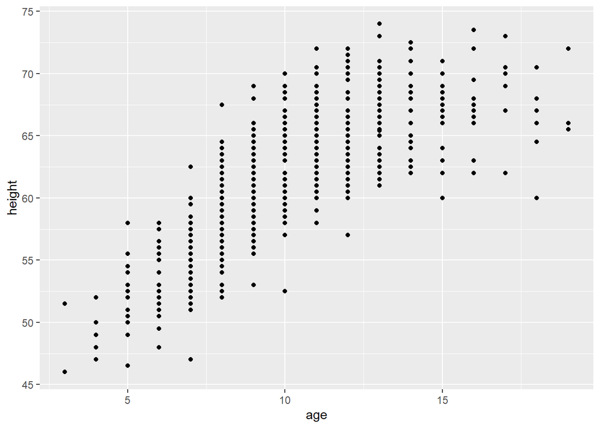

```r
fev_data %>%
  ggplot() +
  geom_point(aes(x=age, y=height))
```

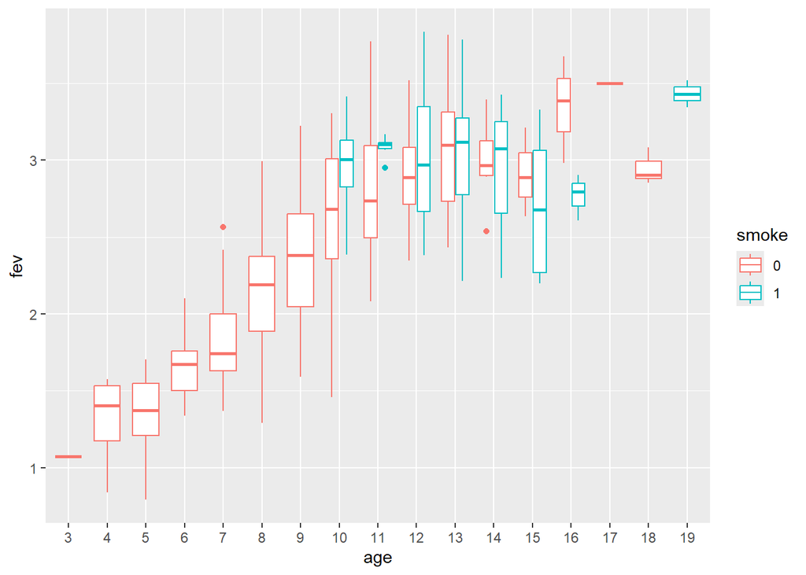

```r
fev_data$age <- factor(fev_data$age)
fev_data$smoke <- factor(fev_data$smoke)
fev_data %>% filter(sex==0) %>%
  ggplot() +
  geom_boxplot(aes(x = age, y = fev, colour = smoke))
```

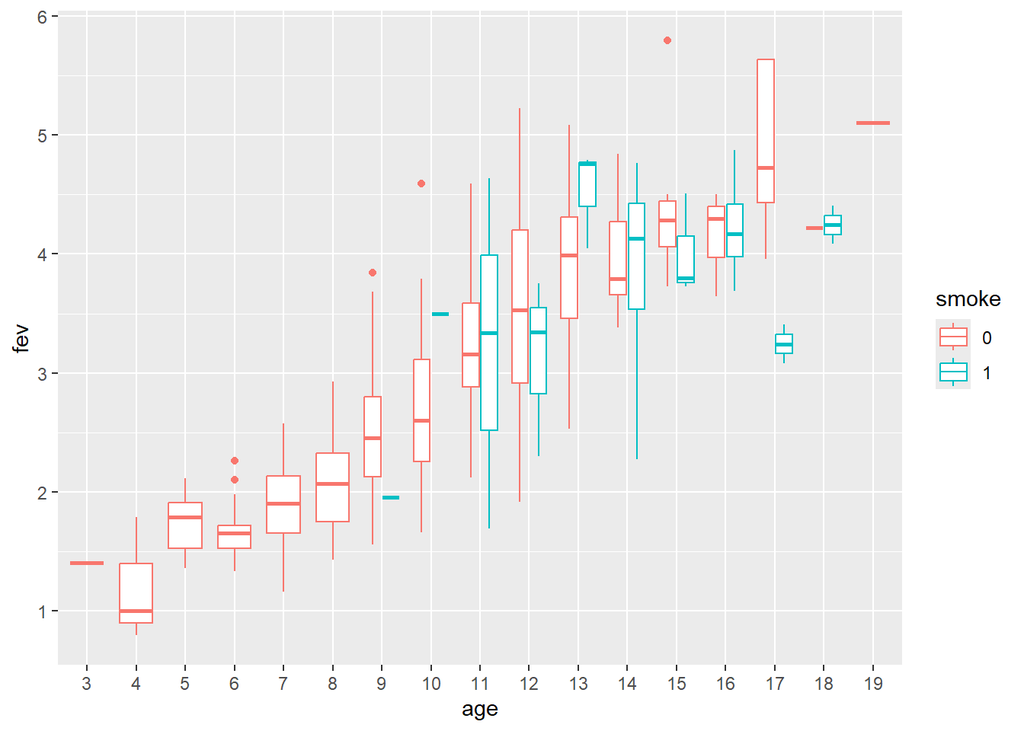

```r
fev_data %>% filter(sex==1) %>%
  ggplot() +
  geom_boxplot(aes(x = age, y = fev, colour = smoke))
```

```r
#Because they are older and taller and have larger lungs
```

Useful function: rename

```r
fev_data %>%
  rename(ID = subjid)
```

| seqnbr | ID | age | fev | height | sex | smoke |
| --- | --- | --- | --- | --- | --- | --- |
| 1 | 301 | 9 | 1.708 | 57.0 | 0 | 0 |
| 2 | 451 | 8 | 1.724 | 67.5 | 0 | 0 |
| 3 | 501 | 7 | 1.720 | 54.5 | 0 | 0 |
| 4 | 642 | 9 | 1.558 | 53.0 | 1 | 0 |
| 5 | 901 | 9 | 1.895 | 57.0 | 1 | 0 |
| 6 | 1701 | 8 | 2.336 | 61.0 | 0 | 0 |
| 7 | 1752 | 6 | 1.919 | 58.0 | 0 | 0 |
| 8 | 1753 | 6 | 1.415 | 56.0 | 0 | 0 |
| 9 | 1901 | 8 | 1.987 | 58.5 | 0 | 0 |
| 10 | 1951 | 9 | 1.942 | 60.0 | 0 | 0 |

[output cut: 644 more lines]

Mutate: compute new column

```r
fev_data %>%
  mutate(heightdiff = height - mean(height))
```

| seqnbr | subjid | age | fev | height | sex | smoke | heightdiff |
| --- | --- | --- | --- | --- | --- | --- | --- |
| 1 | 301 | 9 | 1.708 | 57.0 | 0 | 0 | -4.143578 |
| 2 | 451 | 8 | 1.724 | 67.5 | 0 | 0 | 6.356422 |
| 3 | 501 | 7 | 1.720 | 54.5 | 0 | 0 | -6.643578 |
| 4 | 642 | 9 | 1.558 | 53.0 | 1 | 0 | -8.143578 |
| 5 | 901 | 9 | 1.895 | 57.0 | 1 | 0 | -4.143578 |
| 6 | 1701 | 8 | 2.336 | 61.0 | 0 | 0 | -0.143578 |
| 7 | 1752 | 6 | 1.919 | 58.0 | 0 | 0 | -3.143578 |
| 8 | 1753 | 6 | 1.415 | 56.0 | 0 | 0 | -5.143578 |
| 9 | 1901 | 8 | 1.987 | 58.5 | 0 | 0 | -2.643578 |
| 10 | 1951 | 9 | 1.942 | 60.0 | 0 | 0 | -1.143578 |

[output cut: 644 more lines]

Remember that to save these changes you need to assign to a new tibble:

```r
new_fev_data <- fev_data %>%
  rename(id = subjid) %>%
  mutate(heightdiff = height - mean(height))
```